# Statistics training

```r
ages <- c(10, 20, 30, 40 , 50)
```

```r
summary(ages)
```

```
   Min. 1st Qu.  Median    Mean 3rd Qu.    Max.
     10      20      30      30      40      50
```

# Work with the data set

## Import the data set

```r
summary(data$age_years)
```

```r
table(data$purpose)
```

```r
lm(credit_amount ~ age_years, data)
```

### Show measures of spread

Provide a summary

```r
summary(data$credit_amount)
```

Visualize the data to detect possible outliers

```r
plot(data$credit_amount)
```

```r
boxplot(data$credit_amount)
```

Basic formula of an outlier:

Mean - 2 * sd

Mean + 2 * sd

```r
outlier_min <- mean(data$credit_amount) - (2* sd(data$credit_amount))
outlier_max <- mean(data$credit_amount) + (2* sd(data$credit_amount))
```

```r
print(outlier_min)
print(outlier_max)
```

```r
data$is_outlier <- ifelse(data$credit_amount < outlier_min | data$credit_amount > outlier_max,
                          "outlier", "regular")
```

```r
library(ggplot2)

plot_1 <- ggplot(aes(x=age_years, y=credit_amount), data = data)
plot_1 + geom_point(aes(colour=is_outlier))
```

```r
mean(data$credit_amount)
```

```r
summary(data$credit_amount)
```

### Percentiles

```r
# use the 'quantile' function to calculate percentiles
quantile(data$credit_amount, 0.95)
```

# Bi-variate statistics

### Using the Co-variance

```r
cov(data$age_years, data$credit_amount)
```

```r
cov(data$duration_months, data$credit_amount)
```

### Using the Correlation

```r
cor(data$age_years, data$credit_amount)
```

```r
cor(data$duration_months, data$credit_amount)
```

Causation research

```r
model_1 <- lm(credit_amount ~ duration_months, data=data)

summary(model_1)
```

### Kendall’s Tau

- numeric
- character (nominal)
- factor (ordinal)
- boolean

```r
cor.test(as.numeric(factor(data$housing)), as.numeric(factor(data$purpose)), method="kendall")
```

```
    Kendall's rank correlation tau

data:  as.numeric(factor(data$housing)) and as.numeric(factor(data$purpose))
z = 0.36433, p-value = 0.7156
alternative hypothesis: true tau is not equal to 0
sample estimates:
        tau
0.009906903
```

# Binomial distribution

```r
dbinom(6, 10, 0.5)
```

```r
trials <- 1:10

probabilities <- numeric(0)


for (x in trials){
  prob <- dbinom(x, 10, 0.5)
  probabilities <- append(probabilities, prob)
}

probabilities
```

Create a table to show the cumulative distribution

```r
probs_table <- data.frame(trial = trials,
                          probability = probabilities,
                          cumulative_probability = cumsum(probabilities))
```

# Normal distribution

## Display the distribution in R

```r
plot(density(data$age_years))
```

```r
random_normal <- rnorm(1000, 35, 8)
plot(density(random_normal))
lines(density(data$age_years), col="red")
```

### Manually calculate a z-score

```r
mean(data$age_years)
```

```r
(50 - mean(data$age_years)) / sd(data$age_years)
```

```r
(35.546 - mean(data$age_years)) / sd(data$age_years)
```

## Check if the data is normally distributed

**H0:** The data is normally distributed.

**H1:** The data is **not** normally distributed.

```r
shapiro.test(data$age_years)
```

`p-value` is significantly lower than `0.05`, so this variable is **not** normally distributed.

This means, we cannot choose a parametric.

- (So not `t-test`, no `anova`, but the **non**-parametric equivalents for these tests).

## First statistical test (2 groups)

Test if the average age of people having a loan for new cars if (significantly) different then people having a loan for used cars.

### Hypotheses

**H0:** The average age of people with loans for used cars is the same.

**H1:** The average age of people with loans for used cars is the **not** same.

### Check for normality of the variable

```r
# filter for only car-related purposes
data_cars <- data[data$purpose %in% c("car (new)", "car (used)"), ]
table(data_cars$purpose)
```

```r
shapiro.test(data_cars$age_years)
```

The `p-value`, is lower than `0.05`, so the data is not normally distributed. We cannot use a parametric test.

### Decide the confidence level (p-value) for our test

For this research we choose a confidence level of `95%`, which means we have a critical boundary for the p-value of `0.05`

### Decide/execute the test that will be used

Based on the fact that the data is not normally distributed, we use for the alternative for a t-test, which is the Mann-Whitney U test, which is in R the `wilcox.test`

```r
wilcox_result <- wilcox.test(age_years ~ purpose, data = data_cars)
wilcox_result
```

```r
wilcox_result$p.value
```

### Analyse results of the test

The p-value is `0.9758`, which is larger than `0.05`, so there is not enough evidence to reject the **H0** hypothesis.

### Draw conclusions (about our hypotheses) for our test

The average age between people for loans with used or new cars, is not significantly different.

### What would the t-test

```r
t.test(data_car_used$age_years,
       data_car_new$age_years)
```

# Ggplot

```r
library(ggplot2)
```

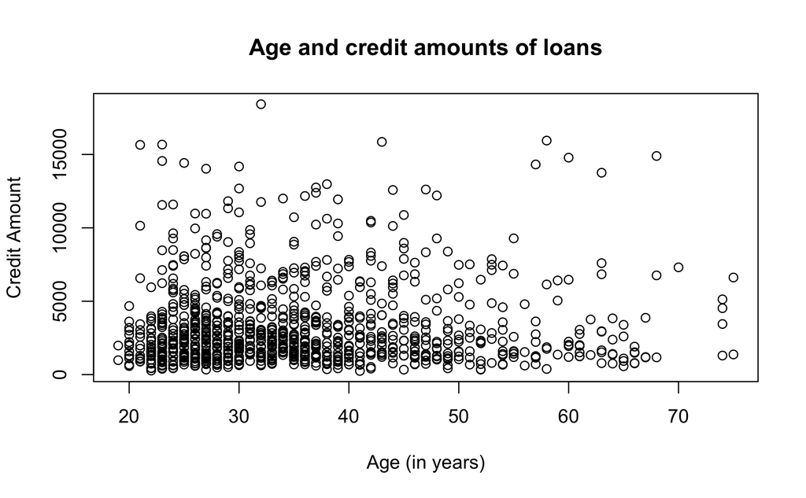

```r
plot_1_r <- plot(x = data$age_years,
                 y = data$credit_amount,
                 xlab = "Age (in years)",
                 ylab = "Credit Amount",
                 main = "Age and credit amounts of loans")
```

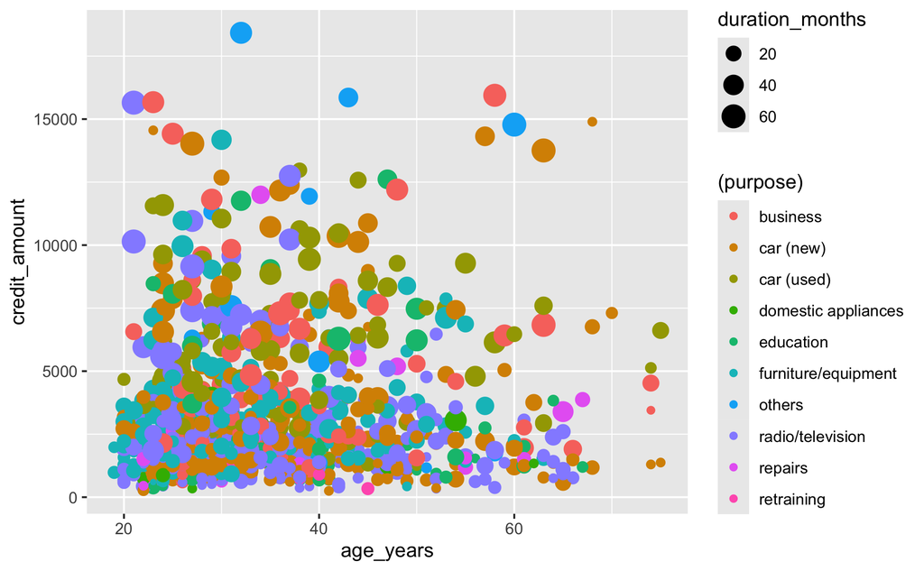

```r
plot_1 <- ggplot(data = data,
                 aes(x = age_years,
                     y = credit_amount))


plot_1 + geom_point(aes(size = duration_months,
                        colour = (purpose)))
```

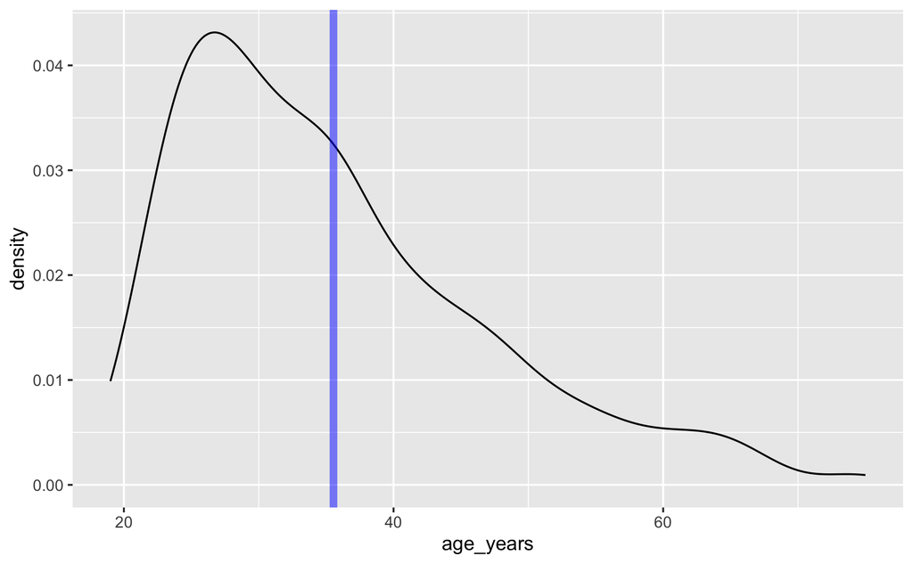

```r
plot_2 <- ggplot(data = data,
                 aes(x=age_years))

plot_2 +
  geom_density() +
  geom_vline(aes(xintercept = mean(age_years)),
             color = "blue",
             size = 2,
             alpha = 0.5)
```

```r
NA
```

### Boxplots in ggplot

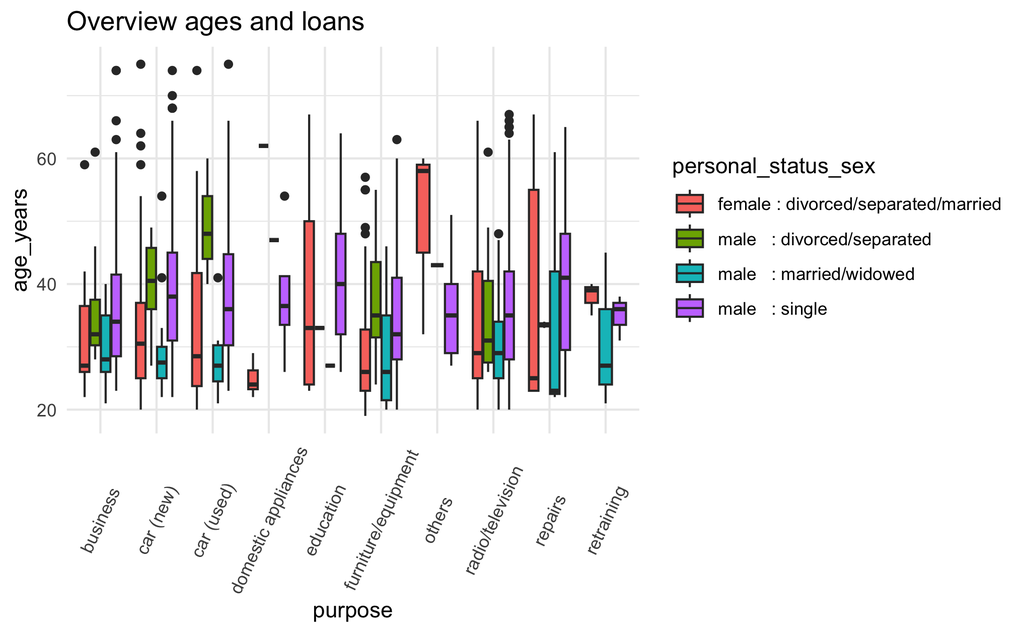

```r
plot_3 <- ggplot(data = data,
                 aes(x = purpose,
                     y = age_years))

plot_3 +
  geom_boxplot(aes(fill = personal_status_sex)) +
  theme_minimal() +
  theme(axis.text.x = element_text(angle=65, vjust=0.5)) +
  labs( title = "Overview ages and loans")
```

## Anova

Check for significant differences between more than 2 groups.

Are these groups **significantly** different **among** each other.

### Create a subset for only loans in these groups

```r
library(dplyr)

selected_groups <- c("car (new)",  "repairs", "radio/television")

data_filtered <- data %>%
  filter(purpose %in% selected_groups)
```

### Hypotheses

**H0:** There is no difference in age_years, among these groups.

**H1:** There is a difference in age_years, among these groups.

### Check for normality

#### a. Visualize the group

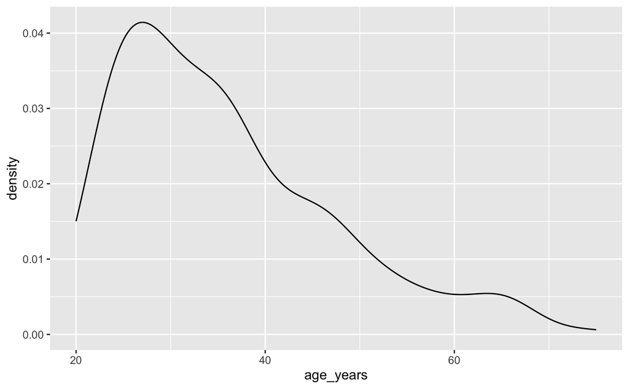

```r
plot_4 <- ggplot(data = data_filtered,
                 aes(x = age_years))

plot_4 + geom_density()
```

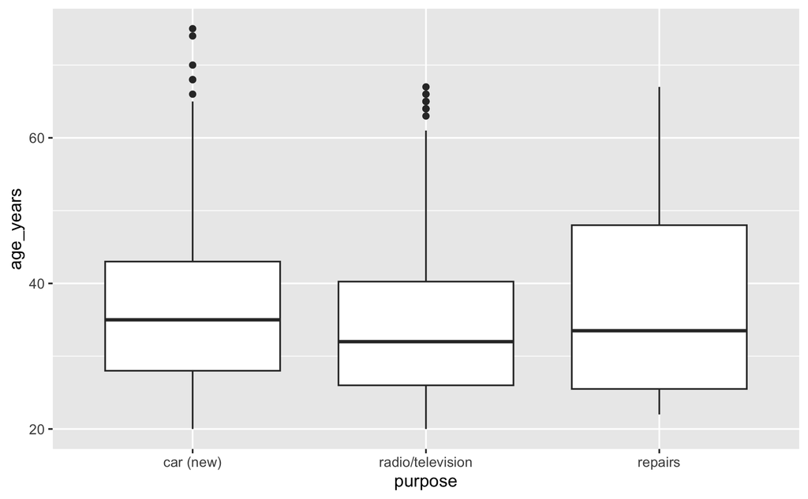

```r
boxplot_groups <- ggplot(data = data_filtered,
                         aes(x = purpose,
                             y = age_years))

boxplot_groups + geom_boxplot()
```

#### b. Apply Shapiro-Wilk test

```r
shapiro.test(data_filtered$age_years)
```

```
    Shapiro-Wilk normality test

data:  data_filtered$age_years
W = 0.91676, p-value < 2.2e-16
```

The p-value is lower than 0.05, so **not** normally distributed.

### Determine the test we will use (based on Normality)

We are using the ANOVA anyway…

### Set our Confidence interval

We use a 95% confidence level. 0.05

### Execute the test

```r
anova_result <- aov(age_years ~ purpose, data = data_filtered)
summary(anova_result)
```

```
             Df Sum Sq Mean Sq F value Pr(>F)
purpose       2    888   444.2   3.373  0.035 *
Residuals   533  70187   131.7
---
Signif. codes:  0 ‘***’ 0.001 ‘**’ 0.01 ‘*’ 0.05 ‘.’ 0.1 ‘ ’ 1
```

### Post-hoc analysis: Which groups differ the most among each other

#### Tukey -test

```r
tuckey_result <- TukeyHSD(anova_result)
tuckey_result
```

[output not shown]

## Anova

Check for significant differences between more than 2 groups.

In this case we have 3 groups:

- Loans for a new car
- Loans for repairs
- Loans for a radio/television

Are these groups **significantly** different **among** each other.

### Hypotheses

**H0:** There is no difference in age_years, among these groups.

**H1:** There is a difference in age_years, among these groups.

### Check for normality

```r
shapiro.test(data_filtered$age_years)
```

### Set confidence-level

95%

### Execute the test

```r
kruskal_test_result <- kruskal.test(age_years ~ purpose, data_filtered)
kruskal_test_result
```

```
    Kruskal-Wallis rank sum test

data:  age_years by purpose
Kruskal-Wallis chi-squared = 7.7187, df = 2, p-value = 0.02108
```

### Analyze the results

The p-value is `0.02108`, we can reject the **H0.**

### Conclusion:

There is a significant difference in ages between thees three **groups.**

### Post-hoc

Post-hoc for Kruskal-Wallis, is **Dunn**-test.

```r
library(dunn.test)

dunn_test_result <- dunn.test(data_filtered$age_years,
                              data_filtered$purpose)
```

```
  Kruskal-Wallis rank sum test

data: x and group
Kruskal-Wallis chi-squared = 7.7187, df = 2, p-value = 0.02

                           Comparison of x by group
                                (No adjustment)
Col Mean-|
Row Mean |   car (new   radio/te
---------+----------------------
radio/te |   2.745156
         |    0.0030*
 repairs |   0.176494  -0.920363
         |     0.4300     0.1787

alpha = 0.05
Reject Ho if p <= alpha/2
```

```r
dunn_test_result
```

```
$chi2
[1] 7.718719

$Z
[1]  2.7451564  0.1764946 -0.9203631

$P
[1] 0.003024103 0.429952710 0.178691512

$P.adjusted
[1] 0.003024103 0.429952710 0.178691512

$comparisons
[1] "car (new) - radio/television" "car (new) - repairs"
[3] "radio/television - repairs"
```

## Chi-squared-test

### See the values of `purpose` and `housing`

```r
data <- data %>%
  filter(!housing == "own")
```

```r
table(data$housing)
```

```
for free     rent
     108      179
```

```r
table(data$purpose)
```

```
           business           car (new)          car (used) domestic appliances           education
                 21                  69                  49                   2                  24
furniture/equipment              others    radio/television             repairs          retraining
                 59                   4                  53                   5                   1
```

Create a contingency table

```r
contig_table_purpose_housing <- table(data$housing, data$purpose)
contig_table_purpose_housing
```

```
           business car (new) car (used) domestic appliances education furniture/equipment others
  for free        5        29         26                   0        15                  11      4
  rent           16        40         23                   2         9                  48      0

           radio/television repairs retraining
  for free               15       3          0
  rent                   38       2          1
```

Check the relative values

```r
contig_table_purpose_housing_relative <- (contig_table_purpose_housing / sum(contig_table_purpose_housing) * 100)

contig_table_purpose_housing_relative
```

```
             business  car (new) car (used) domestic appliances  education furniture/equipment
  for free  1.7421603 10.1045296  9.0592334           0.0000000  5.2264808           3.8327526
  rent      5.5749129 13.9372822  8.0139373           0.6968641  3.1358885          16.7247387

               others radio/television    repairs retraining
  for free  1.3937282        5.2264808  1.0452962  0.0000000
  rent      0.0000000       13.2404181  0.6968641  0.3484321
```

```r
df_contig_table_purpose_housing_relative <- as.data.frame(contig_table_purpose_housing_relative)
```

Visualize in ggplot

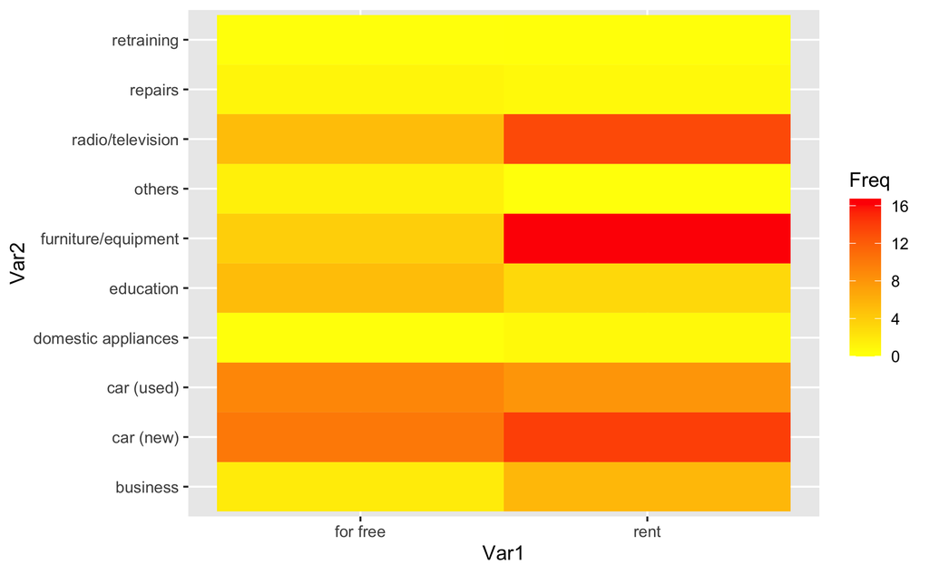

```r
plot_contig_table <- ggplot(data = df_contig_table_purpose_housing_relative,
                            aes(x=Var1,
                                y=Var2,
                                fill=Freq))

plot_contig_table +
  geom_tile() +
  scale_fill_gradient(low = "yellow", high="red")
```

Chi-squared test will summarize the relationship between `housing` and `purpose` as a whole.

## Chi-squared test

### Hypotheses

**H1:** The two groups are dependent from each other

### Confidence level

Our confidence level is set to 95%

### Execute the test

```r
contig_table_purpose_housing <- table(data$housing, data$purpose)
contig_table_purpose_housing
```

```
           business car (new) car (used) domestic appliances education furniture/equipment others
  for free        5        29         26                   0        15                  11      4
  rent           16        40         23                   2         9                  48      0

           radio/television repairs retraining
  for free               15       3          0
  rent                   38       2          1
```

```r
chisq_result <- chisq.test(contig_table_purpose_housing)
chisq_result
```

```
    Pearson's Chi-squared test

data:  contig_table_purpose_housing
X-squared = 34.107, df = 9, p-value = 8.556e-05
```

### Conclusion/hypotheses

We can reject the **H0** hypotheses. The two groups are dependent from each other.

# Poisson distribution

## Import the data set

```r
data_extra <- read_csv("data/german_data_extra.csv")
```

## Analysis of data set

### Aggregate the dates

```r
loans_per_day <- data_extra %>%
  group_by(date) %>%
  summarise(Count = n())
```

```r
loans_per_day
```

| date | Count |
| --- | --- |
| 2018-01-02 | 199 |
| 2018-01-08 | 211 |
| 2018-01-10 | 224 |
| 2018-01-11 | 233 |
| 2018-01-12 | 245 |
| 2018-01-15 | 216 |
| 2018-01-16 | 223 |
| 2018-01-17 | 251 |
| 2018-01-18 | 221 |
| 2018-01-19 | 237 |

[output cut: 990 more lines]

### Summary of the `Count` variable

```r
summary(loans_per_day$Count)
```

```
   Min. 1st Qu.  Median    Mean 3rd Qu.    Max.
  176.0   213.0   224.0   223.9   234.0   278.0
```

To calculate the **lambda**, you need to have the average amount of the column you want to investigate (Count).

```r
lambda_loans <- mean(loans_per_day$Count)
lambda_loans
```

```
[1] 223.8806
```

Create probabilities for loans in a day

```r
poisson_probs_loans <- dpois(loans_per_day$Count, lambda_loans)
```